# Analysis of Samsung S22 and Apple iPhone 13

23/04/2022

# Analysis of Samsung S22 and Apple iPhone 13

This is the analysis for the video submission in the module BU7147 Social Media Analytics of the programme M.Sc. Business Analytics at Trinity Business School. You can also find our code on Github under the following link: https://github.com/mschuermann/Social-Media-Analytics

If one of the visualisations does not show labels or similar, please re-run the chunk and it should work.

## The Smartphone Market

The global smartphone market has experienced multiple market leaders over the past few years. The only two major brands that remained over the years were Apple and Samsung. Those two brands are compared regularly and are competing over the market share. While Samsung was the market leader in the first three quarters in 2021. In September 2021, Apple released its new iPhone model with the generation 13 and gained market share, taking over the market leader position. In February 2022, Samsung also released the new model in its Galaxy series. Those two phones are the flagships in the current smartphone market.

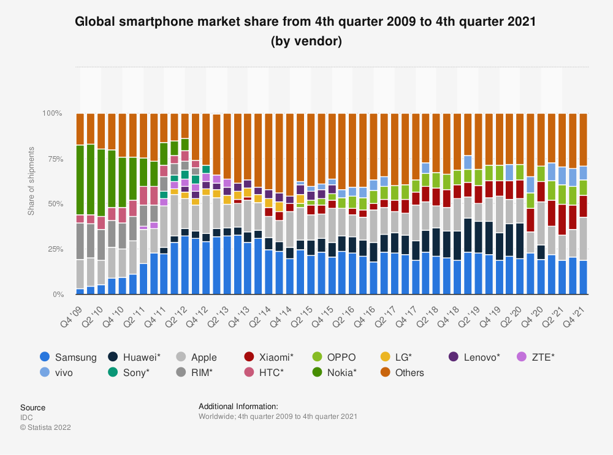

Source: [IDC. (2022). Global smartphone market share from 4th quarter 2009 to 4th quarter 2021 (by vendor). Statista. Statista Inc..](https://www.statista.com/statistics/271496/global-market-share-held-by-smartphone-vendors-since-4th-quarter-2009/) Accessed: April 14, 2022.

## Samsung Galaxy S22

The Samsung Galaxy S series is the high-end model produced and sold by Samsung, a South Korean multinational electronics company. The S series has 13 generations. Together with the Galaxy Z and Galaxy Note (discontinued) series, the S series serves as flagship models ([Wikipedia, n.d.)](https://en.wikipedia.org/wiki/Samsung_Galaxy_S_series). Samsung S series uses the open source operating system Android ([Samsung](https://www.samsung.com/ie/smartphones/galaxy-s22-ultra/)).

Samsung advertises the S22 series with the following features:

- "The phone that makes everyday epic
- Nightography camera
- A battery that lasts the day and beyond
- Our fastest chip ever"

(Source: [Samsung](https://www.samsung.com/ie/smartphones/galaxy-s22/))

[figure not shown]

[Picture Source](https://img.global.news.samsung.com/global/wp-content/uploads/2022/02/Galaxy-S22-S22-pr_main1.jpg)

## Apple iPhone 13

The Apple iPhone series is the only smartphone series produced and sold by Apple Inc, an US-American multinational technology company ([Wikipedia](https://en.wikipedia.org/wiki/IPhone)).

Apple advertises the iPhone Pro with the following features:

- "A dramatically more powerful camera system.
- A display so responsive, every interaction feels new again.
- The world’s fastest smartphone chip.
- Exceptional durability.
- And a huge leap in battery life." ([Samsung](https://www.apple.com/iphone-13-pro/))

[figure not shown]

[Picture Source](https://www.apple.com/newsroom/images/product/iphone/standard/Apple-iPhone13-Pro-color-lineup-220308_big_carousel.jpg.slideshow-xlarge.jpg)

## Comparison of Features

|  | Samsung S22 | Apple iPhone 13 |
| --- | --- | --- |
| **Starting Price** | $799 | $799 |
| **Screen size** | 6.1 inches (2340 x 1080) | 6.1 inches (2532 x 1170) |
| **Refresh rate** | 48Hz-120Hz adaptive | 60Hz |
| **CPU** | Snapdragon 8 Gen 1 (US); Exynos 2200 (K) | A15 Bionic |
| **RAM** | 8GB | 4GB (based on teardowns) |
| **Storage** | 128GB, 256GB | 128GB, 256GB, 512GB |
| **Rear cameras** | 50MP wide (f/1.8); 12MP ultrawide (f/2.2); 10MP telephoto (f/2.4) with 3x optical zoom | 12MP main (f/1.6), 12MP ultrawide (f/2.4) |
| **Front camera** | 10MP (f/2.2) | 12MP (f/2.2) |
| **Battery size** | 3,700 mAh | 3,227 mAh (based on teardowns) |
| **Battery life (Hrs:Mins)** | 7:51 | 10:33 |
| **Charging speeds** | 25W wired, 15W wireless | 20W wired; 15W wireless |
| **Size** | 5.7 x 2.8 x 0.3 inches | 5.8 x 2.8 x 0.3 inches |
| **Weight** | 5.9 ounces | 6.14 ounces |
| **Colors** | Black, white, green, pink gold | Black, white, blue, pink, red, green |

Source: https://www.tomsguide.com/face-off/samsung-galaxy-s22-vs-iphone-13

## Objectives of our Research

- Identification of the strengths and weaknesses of the competitor models which can help to identify a gap in a market and enhancing the own business strategy.
- Identification of suggestions to customers about the products based on other customers’ opinions

## Methodology of our Research

We used data from Twitter API and Amazon Reviews to get information towards our research objective.

We used the following methods:

- Word Frequencies,
- Sentiment Analysis,
- Word Correlations,
- Clustering and
- LDA Topic Modelling.

# Twitter Analysis

## Data Extraction and Cleaning

### Samsung S22

We decided to extract data from Twitter with the keywords “Samsung S22” and the hashtag “#samsungs22” from 31.03.2022 - 08.04.2022 as we do not have a premium license to get access to the full timeline of tweets on the TwitterAPI.

We excluded from our query the users ShopeeID, _arllee and all retweets for the keywords “Samsung S22” because there were multiple thousands of tweets about a competition to win a Samsung mobile phone which caused a lot of duplicated data.

As well, we identified nine users which were creating advertising spam and non-valuable tweets that we had to exclude: “whitestonedome”, “FromKorea5”, “dome_glass”, “Whitestone_DE”, “whitestone_UK”, “jp_whitestone”, “Whitestone__FR”, “WhitestoneJapan”, “WhitestoneEU”.

In total we could gather 3846 tweets.

Our initial data frame has 17 attributes. You can find the meaning of each of the attributes here on the [Twitter Developer Platform](https://developer.twitter.com/en/docs/twitter-api/v1/data-dictionary/object-model/tweet).

### Apple iPhone 13

We extracted data for the search terms “iPhone 13” excluding retweets and the hashtag “#iphone13” from the TwitterAPI. Similarly, to the Samsung S22 we had to exclude certain users which were advertising (“whitestonedome”, “FromKorea5”, “domeglassapple”) and competitions to win an iPhone when retweeting or copy-pasting a specific text (“Join the event to win an iPhone 13!”). Also, we had a high number of tweets which were randomly posting brand names, e.g. “rolex iphone” in one tweet.

In total we could gather 8369 tweets.

Our initial data frame has 17 attributes. You can find the meaning of each of the attributes here on the [Twitter Developer Platform](https://developer.twitter.com/en/docs/twitter-api/v1/data-dictionary/object-model/tweet).

## How Many Users Were Posting How Many Tweets in the Dataset?

While there were only 3846 tweets from users about the Samsung S22, there were 2.17 times more tweets about the Apple iPhone 13 during the period considered.

From a brand perspective, Samsung has more searches overall than Apple; and from their latest models, iPhones have more searches than Samsung mobile phones. This result may be because Samsung has a more diverse product range and series [Korea Expose](https://www.koreaexpose.com/samsung-products-basic-information/#:~:text=Samsung%20Electronics%2C%20the%20largest%20subsidiary,and%20security%2Fmonitoring%20systems%2C%20to) than Apple [Apple Wiki](https://apple.fandom.com/wiki/List_of_Apple_products), but within the flagship phones of their brands, iPhone is getting more attention than Samsung S22. Apple has more topicality in the online discussions which might due to their marketing strategy or people just like to give attention and being involved in the discussion of their new product releasing.

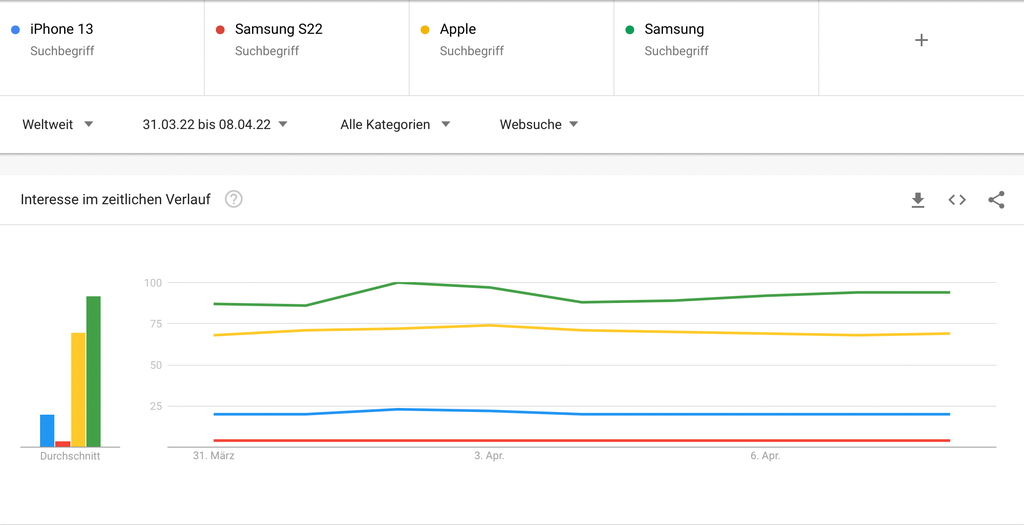

There are more tweets than users which indicates that some users usually post more than one tweet. We calculated a ratio for this: `avg_tweets_per_user = tweets per day / users per day`.

## Wordcloud

### Data Preprocessing

We decided to preprocess the data based on the following steps:

- All text was converted to lower case, e.g. Hello to hello.
- All contractions were converted to the longer form, e.g. don’t to do not
- All common internet slang was converted to formal English, e.g. TGIF to Thanks God it is Friday
- Hashtags (#) were removed
- Word elongation was replaced to the usual word form, e.g. heeeeey to hey
- All non-ASCII characters were replaced with equivalent or removed, **©** to (C)
- White space within the string is reduced to one white space
- White space at the start and end of the string was removed
- “RT”, implicating that its a retweet was removed
- all links were removed based on the start of “http”
- all @username were removed
- punctuation were removed
- stop words were removed based on the RegEx approach

### Results

```r
wordcloud(word_s, min.freq = 60, max.words = 40, random.order = FALSE, color= pal)
```

[output not shown]

Samsung S22 users mentioned Samsung, Galaxy (which is the series of the S22) and Ultra (which is a specific model). The Ultra model is comparable to the iPhone 13 Pro.

Also iPhone, Pro, Max, Note & OnePlus are mentioned which are other comparable smartphones in the market.

Other words that are often mentioned belong to specifications that users talked about:

- android, update, security
- camera, pixel, video
- features
- mediatek
- screen
- case

```r
wordcloud(word_a, min.freq = 60, max.words = 40, random.order = FALSE, color= pal)
```

[output not shown]

We can identify that Apple iPhone is mentioned in the variants Pro, Mini and Max. Pro seems to be the most important one, then Max and then the Mini.

As with the Samsung S22, also here it is mentioned with “Ultra”, “Galaxy” and “Samsung”.

The specifications of the phone that users talked about were:

- pixel, camera
- battery
- price
- case
- green

For iPhone 13, we can notice that some adjectives and verbs were mentioned a lot:

available, buy, win, free, still, now, good, better, best, like, will, get, want, need, can

### Insights

Both models are mentioned with their camera and pixel but only Samsung has the word “video” mentioned a lot. We identified in our pre-research about the phones that both companies advertise their smartphones based on the camera. None of both mentions about positive abilities in the video recording in their main advertisement.

For Samsung S22 users it seems to be important that a new update has been released. A new Android OS update for the series S22 has been released in April 2022 and updated security measurements and brought new features.

For Apple iPhone 13 it has been talked a lot about green. The generation 13 has been the first Flagship model to be produced in this colour, therefore it makes sense that people discuss about it.

## Sentiment Analysis

### Preprocessing Tweets

We need to preprocess data this time additionally with the following steps:

- Emojis were replaced by the word form, e.g. Smiling emoji to smiling
- Emoji Identifier were replaced by the word form, e.g. :-) to smiling

```r
stopwords_regex <- paste(stopwords('en'), collapse = '\\b|\\b')
stopwords_regex <- paste0('\\b', stopwords_regex, '\\b')

Samsung_df <- samsung_df$text %>%
  str_to_lower() %>% #all text to lower case
  replace_contraction() %>% #replaces contractions to longer form
  replace_internet_slang() %>% #replaces common internet slang
  replace_hash(replacement = "") %>% #removes hashtags
  replace_word_elongation() %>% #removes word elongation, e.g. "heeeeey" to "hey"
  replace_emoji() %>% #replaces emojis with the word form
  replace_emoji_identifier() %>% #replaces emoji identifiers to word form
  replace_non_ascii() %>% #replaces common non-ASCII characters.
  str_squish() %>% #reduces repeated whitespace inside a string
  str_trim() %>% #removes whitespace from start and end of string
  {gsub("(RT|via)((?:\\b\\W*@\\w+)+)","",.)} %>% #remove RT (retweets)
  {gsub("http[^[:blank:]]+","",.)} %>% #remove links that start with http
  {gsub("@\\u+","",.)} %>% #remove names
  {gsub('@\\w+', '', .)} %>% # remove at people
  {gsub("[[:punct:]]"," ",.)} %>%#remove punctuation
  {gsub("[^[:alnum:]]"," ",.)}%>%#remove punctuation
  {gsub("pro"," ",.)}%>%#removes the word "pro" because its a different context herein
  stringr::str_replace_all(stopwords_regex, '') %>% #remove stop words
  make_plural() %>%
  unique()#remove duplicates

tail(Samsung_df)
```

[output not shown]

### Sentiments in Tweets

In the first step, we wanted to identify the general sentimental view for each of the two brands. Because we have different sizes in the data sets (Apple iPhone 13 database is larger than Samsung S22), we could not compare them in absolute numbers but had to compare relative values.

```r
relative_comp_sentiment <- data.frame(Sentiment = sentimentscores_apple$sentiment, Apple_iPhone_13 = sentimentscores_apple$score/sum(sentimentscores_apple$score)*100, Samsung_S22 = sentimentscores$score/sum(sentimentscores$score)*100) %>%
  melt(id.vars = 1, variable.name = "variable",
           value.name="score")

ggplot(relative_comp_sentiment, aes(x= Sentiment, y= score, fill=variable)) +
  geom_bar(position="dodge",  stat="identity") +
  xlab("sentiment") +ylab("percentage")+ ggtitle("Relative Sentiment Score based on Tweets about Apple and Samsung")
```

[output not shown]

On the first look, sentiments are similar for both smartphone models and are commented on with highly positive sentiments. This means that on both models, users are generally speaking positively about their smartphone.

Samsung S22 has more trust and anticipation while iPhone 13 brings more joy to its users but also more sadness, surprise, fear and disgust.

```r
###### Sentimentr score #######
sentimentr_apple <- sentiment_by(Apple_df, by=NULL)
# You can see the sentiment per tweet ID:
ggplot(data=sentimentr_apple,aes(x=element_id,y=ave_sentiment, color=ave_sentiment))+
  geom_line()
# You can see the summary of minimum, IQR, median and mean for all variables. For us, word_count and ave_sentiment are mostly interesting:
summary(sentimentr_apple)

# You can see the variance and standard deviation for the Sentiment Score & Word Count:
data.frame(" "= c("Average", "Variance", "Standard Deviation"),
"Sentiment Score" = c(round(mean(sentimentr_apple$ave_sentiment),2), round(var(sentimentr_apple$ave_sentiment),2),
round(sd(sentimentr_apple$ave_sentiment),2)),
"Word Count"=c(round(mean(sentimentr_apple$word_count),2), round(var(sentimentr_apple$word_count),2),
round(sd(sentimentr_apple$word_count),2)))

library(scales)
#rescale to a scale of 1 to 5
a_tweets_scale_5 <- sentimentr_apple$ave_sentiment %>%
  rescale(to = c(1,5), from = c(-1,1)) %>%
  mean()
```

[output not shown]

```r
##### Sentimentr score ######
sentimentr_samsung <- sentiment_by(Samsung_df, by=NULL)
# You can see the sentiment per tweet ID:
ggplot(data=sentimentr_samsung,aes(x=element_id,y=ave_sentiment, color=ave_sentiment))+
  geom_line()

# You can see the summary of minimum, IQR, median and mean for all variables. For us, word_count and ave_sentiment are mostly interesting:
summary(sentimentr_samsung)

# You can see the variance and standard deviation for the Sentiment Score & Word Count:
data.frame(" "= c("Average", "Variance", "Standard Deviation"),
"Sentiment Score" = c(round(mean(sentimentr_samsung$ave_sentiment),2), round(var(sentimentr_samsung$ave_sentiment),2),
round(sd(sentimentr_samsung$ave_sentiment),2)),
"Word Count"=c(round(mean(sentimentr_samsung$word_count),2), round(var(sentimentr_samsung$word_count),2),
round(sd(sentimentr_samsung$word_count),2)))

#rescale to a scale of 1 to 5
s_tweets_scale_5 <- mean(rescale(sentimentr_samsung$ave_sentiment, to = c(1,5), from = c(-1,1)))
```

[output not shown]

The sentimentr package in R estimates the sentiment polarity by sentence. The average sentiment for iPhone 13 was higher distributed with a range from -1.6 to +1.9 with its average at 0.26 while Samsung had a sentiment polarity from -1.1 to +1.6 with its average at 0.15. The higher variance within the data is identical to our findings from the plot “Relative Sentiment Score based on Tweets about Apple and Samsung” earlier. We can see from this that iPhone 13 users are in general more emotional - in a negative and positive direction - than Samsung S22 users. We assume that people are emotionally more dependent on their iPhone 13 than Samsung S22.

## Word Correlation

### Samsung S22

### Apple iPhone 13

## Clustering

```r
tdm_s <- corpus<- Corpus(VectorSource(word_s))
tdm_s <- TermDocumentMatrix(tdm_s)
tdm_s2 <- removeSparseTerms(tdm_s, sparse = 0.95)
ms2 <- as.matrix(tdm_s2)
# cluster terms
distMatrix_s <- dist(scale(ms2))
fit_s <- hclust(distMatrix_s, method = "ward.D")
plot(fit_s)
rect.hclust(fit_s, k = 3, border = "red") # cut tree into 9 clusters
```

[output not shown]

```r
tdm_a <- corpus<- Corpus(VectorSource(word_a))
tdm_a <- TermDocumentMatrix(tdm_a)
tdm_a2 <- removeSparseTerms(tdm_a, sparse = 0.95)
ma2 <- as.matrix(tdm_a2)
# cluster terms
distMatrix_a <- dist(scale(ma2))
fit_a <- hclust(distMatrix_a, method = "ward.D")
plot(fit_a)
rect.hclust(fit_a, k = 3,border = "red") # cut tree into 9 clusters
```

[output not shown]

## LDA Topic Modelling

### Samsung S22

### Apple iPhone 13

# Amazon Review Analysis

For further analysis, we have decided to analyse the Amazon product reviews for both the phones in order to understand if the sentiments of customers on Twitter and Amazon were matching or not.

To do this, the first step was to collect the data. We faced a similar situation for collecting the data, Samsung S22 had very few reviews and the iPhone 13 had a large amount of reviews. So, to collect more data, we used Amazon reviews from different country websites like UK, India, USA and Australia. Specifically, English reviews were selected to proceed with the analysis.

We have to admit that there is only one review section for all Samsung models in the variants of the series S22. The same is valid for all variants of iPhone 13 series.

The following R code was implemented to collect data from different Amazon websites. ([<https://martinctc.github.io/blog/vignette-scraping-amazon-reviews-in-r/>](https://martinctc.github.io/blog/vignette-scraping-amazon-reviews-in-r/))

## Scraping of Amazon Product Reviews

```r
# #Scraping Product Reviews from Amazon
#
# #import libraries
# library(rvest)
# library(stringr)
# library(xml2)
# library(tidyverse)
#
#
# scrape_amazon <- function(ASIN, page_num){
#
#   #amazon_uk
#   #url_reviews <- paste0("https://www.amazon.co.uk/product-reviews/",ASIN,"/?pageNumber=",page_num)
#   #amazon.com
#   #url_reviews <- paste0("https://www.amazon.com/product-reviews/",ASIN,"/?pageNumber=",page_num)
#   #amazon.in
#   #url_reviews <- paste0("https://www.amazon.in/product-reviews/",ASIN,"/?pageNumber=",page_num)
#
#   #amazon.com.au
#   url_reviews <- paste0("https://www.amazon.com.au/product-reviews/",ASIN,"/?pageNumber=",page_num)
#
#   doc <- read_html(url_reviews) # Assign results to `doc`
#
#   # Review Title
#   doc %>%
#     html_nodes("[class='a-size-base a-link-normal review-title a-color-base review-title-content a-text-bold']") %>%
#     html_text() -> review_title1
#
#   review_title <- str_squish(review_title1)
#
#   # Review Text
#   doc %>%
#     html_nodes("[class='a-size-base review-text review-text-content']") %>%
#     html_text() -> review_text1
#
#   review_text <- str_squish(review_text1)
#
#   # Number of stars in review
#   doc %>%
#     html_nodes("[data-hook='review-star-rating']") %>%
#     html_text() -> review_star1
#
#   review_star <- str_squish(review_star1)
#
#   # Date
#
#   doc %>%
#     html_nodes("[data-hook='review-date']") %>%
#     html_text() -> review_date1
#   review_date <- str_squish(review_date1)
#
#   # Return a tibble
#  tibble(review_title,
#          review_text,
#          review_star,
#          review_date,
#          page = page_num) %>% return()
# }
#
#
# ASIN <- "B09MW17JQY" # Specify ASIN
# page_range <- 1 # Let's say we want to scrape pages 1 to 10
#
# match_key <- tibble(n = page_range,
#                     key = sample(page_range,length(page_range)))
#
# lapply(page_range, function(i){
#   j <- match_key[match_key$n==i,]$key
#
#   message("Getting page ",i, " of ",length(page_range), "; Actual: page ",j) # Progress bar
#
#   Sys.sleep(3) # Take a three second break
#
#   if((i %% 3) == 0){ # After every three scrapes... take another two second break
#
#     message("Taking a break...") # Prints a 'taking a break' message on your console
#
#     Sys.sleep(2) # Take an additional two second break
#   }
#   scrape_amazon(ASIN = ASIN, page_num = j) # Scrape
# }) -> output_list
#
#
# write.csv(output_list,"C:\\Users\\Shruthi\\OneDrive\\Documents\\Semester 2\\Social Media Analytics\\Group Assignment\\Samsung_Australia.csv",row.names = FALSE)

### We repeated this step for Amazon UK, US, India for iPhone 13 models and Samsung S22 models.
```

## Wordcloud

### Samsung S22 Reviews

```r
samsung.reviews.text <- samsung.reviews$review_text %>%
  str_to_lower() %>% #all text to lower case
  replace_contraction() %>% #replaces contractions to longer form
  replace_internet_slang() %>% #replaces common internet slang
  replace_hash(replacement = "") %>% #removes hashtags
  replace_word_elongation() %>% #removes word elongation, e.g. "heeeeey" to "hey"
  str_squish() %>% #reduces repeated whitespace inside a string
  str_trim() %>% #removes whitespace from start and end of string
  {gsub("(RT|via)((?:\\b\\W*@\\w+)+)","",.)} %>% #remove RT (retweets)
  {gsub("http[^[:blank:]]+","",.)} %>% #remove links that start with http
  {gsub("@\\u+","",.)} %>% #remove names
  {gsub('@\\w+', '', .)} %>% # remove at people
  {gsub("[[:punct:]]"," ",.)} %>%#remove punctuation
  {gsub("[^[:alnum:]]"," ",.)}%>%#remove punctuation
  str_replace_all("issue", "issues") %>%
  removeNumbers() %>%
  removeWords(stopwords("english")) %>%
  make_plural() %>%
  stringr::str_replace_all(stopwords_regex, '') %>% #remove stop words
  unique() #remove duplicates

samsung.reviews.text <- data.frame(samsung.reviews.text)
```

### iPhone 13 reviews

```r
iphone.reviews.text <- iphone.reviews$review_text %>%
  str_to_lower() %>% #all text to lower case
  replace_contraction() %>% #replaces contractions to longer form
  replace_internet_slang() %>% #replaces common internet slang
  replace_hash(replacement = "") %>% #removes hashtags
  replace_word_elongation() %>% #removes word elongation, e.g. "heeeeey" to "hey"
  str_squish() %>% #reduces repeated whitespace inside a string
  str_trim() %>% #removes whitespace from start and end of string
  {gsub("(RT|via)((?:\\b\\W*@\\w+)+)","",.)} %>% #remove RT (retweets)
  {gsub("http[^[:blank:]]+","",.)} %>% #remove links that start with http
  {gsub("@\\u+","",.)} %>% #remove names
  {gsub('@\\w+', '', .)} %>% # remove at people
  {gsub("[[:punct:]]"," ",.)} %>%#remove punctuation
  {gsub("[^[:alnum:]]"," ",.)}%>%#remove punctuation
  removeNumbers() %>%
  removeWords(stopwords("english")) %>%
  str_replace_all("issue", "issues") %>%
  make_plural() %>%
  stringr::str_replace_all(stopwords_regex, '') %>% #remove stop words
  unique() #remove duplicates

iphone.reviews.text <- data.frame(iphone.reviews.text)
```

## Sentiment Analysis

### Samsung S22

### Apple iPhone 13

### Comparison of Average Sentiments in Text to Score given by Users

```r
#Samsung
# rescale the range to 5 star range.
bing.mean.score_s<-rescale(bing.mean.score_s$mean, to = c(1,5), from = c(-1,1))

# Afinn scores are from -5 to 5.
afinn.mean.score_s <- word.freq.table_s %>%
  inner_join(get_sentiments("afinn"))%>%
  summarise(Samsung_mean = mean(value))

# rescale the range to 5 star range.
afinn.mean.score_s<-rescale(afinn.mean.score_s$Samsung_mean, to = c(1,5), from = c(-5,5))

#Apple
# rescale the range to 5 star range.
bing.mean.score_a<-rescale(bing.mean.score_a$mean, to = c(1,5), from = c(-1,1))

# Afinn scores are from -5 to 5.
afinn.mean.score_a <- word.freq.table_a %>%
  inner_join(get_sentiments("afinn"))%>%
  summarise(Apple_mean = mean(value))

# rescale the range to 5 star range.
afinn.mean.score_a<-rescale(afinn.mean.score_a$Apple_mean, to = c(1,5), from = c(-5,5))
afinn.mean.score_a

samsung.review.stars <- samsung.reviews$review_star %>%
  substr(1,3) %>%
  as.numeric() %>%
  mean() %>%
  round(1)

iphone.review.stars <- iphone.reviews$review_star %>%
  substr(1,3) %>%
  as.numeric() %>%
  mean() %>%
  round(1)


compare.stars <- data.table(
  "Metric"= c("Average 5-Star-Score identified from Sentiments", "Average 5-Star-Score given by users", "Average 5-Star-Score identified from Tweets"),
  "Samsung S22"=c(round(afinn.mean.score_s, digits=1), samsung.review.stars, round(s_tweets_scale_5,1)),
  "iPhone 13" = c(round(afinn.mean.score_a, digits=1), iphone.review.stars, round(s_tweets_scale_5,1)))
compare.stars
```

[output not shown]

## Word Correlation

```r
# Correlation Terms
# The correlation of appearing together in a review
samsung.correlation.terms <- samsung.reviews.text %>%
  mutate(review = row_number()) %>%
  unnest_tokens(word, samsung.reviews.text) %>%
  filter(!word %in% stop_words$word) %>%
  filter(!word %in% c("days", "protector")) %>%
  group_by(word) %>%
  filter(n() >=7)%>%
  pairwise_cor(word, review, sort = TRUE)
samsung.correlation.terms

library(ggraph)
library(igraph)
samsung.correlation.terms %>%
  filter(correlation >= 0.55) %>%
  graph_from_data_frame() %>%
  ggraph(layout = "igraph", algorithm = "kk") +
  geom_edge_link(aes(alpha = correlation),
                 show.legend = FALSE)+
  geom_node_point(color = "lightblue", size = 2) +
  geom_node_text(aes(label = name), repel = TRUE) +
  theme_void()+
  ggtitle("Correlation of terms in Samsung S22 Reviews")
```

[output not shown]

Which words are correlating with each other and what is it related to?

```r
# Correlation Terms
# The correlation of appearing together in a review
apple.correlation.terms <- iphone.reviews.text %>%
  mutate(review = row_number()) %>%
  unnest_tokens(word, iphone.reviews.text) %>%
  filter(!word %in% stop_words$word) %>%
  group_by(word) %>%
  filter(n() >= 5)%>%
  pairwise_cor(word, review, sort = TRUE)
apple.correlation.terms

library(ggraph)
library(igraph)
apple.correlation.terms %>%
  filter(correlation >= 0.55) %>%
  graph_from_data_frame() %>%
  ggraph(layout = "igraph", algorithm = "kk") +
  geom_edge_link(aes(alpha = correlation),
                 show.legend = FALSE)+
  geom_node_point(color = "lightblue", size = 2) +
  geom_node_text(aes(label = name), repel = TRUE) +
  theme_void()+
  ggtitle("Correlation of terms in Apple iPhone 13 Reviews")
```

[output not shown]

```r
# now we find the centrality measures of the network
# degree:the number of its adjacent edges (measure of direct influence)
deg_s <- degree(bigrams.network_s, mode = "all")

#K-core decomposition allows us to identify the core and the periphery of the network. A k-core is a maximal subnet of a network such that all nodes have at least degree K.
core_s <- coreness(bigrams.network_s, mode = "all")

# betweenness measures brokerage or gatekeeping potential. It is (approximately) the number of shortest paths between nodes that pass through a particular node.
betw_s <- betweenness(bigrams.network_s)

#Eigenvector centrality is a measure of being well-connected connected to the well-connected. First eigenvector of the graph adjacency matrix. Only works with undirected networks.
eigen_s <- eigen_centrality(bigrams.network_s, directed = TRUE)
members_s <- cluster_walktrap(bigrams.network_s)

library(igraph)
bigrams.network_s <- simplify(bigrams.network_s
                            #remove.multiple = FALSE, #error occured ?
                            #remove.loops = TRUE)
)
V(bigrams.network_s)$color <- members_s$membership+1

# Using "Coreness" as size
# Coreness -> mean (average distance to all the other nodes, diffusion of information)
plot(bigrams.network_s,
     layout = layout_with_fr,
     vertex.label.color = "black",
     vertex.label.cex = 0.9,
     vertex.label.dist = 0,
     vertex.frame.color = 0,
     vertex.size = core_s*10,
     edge.arrow.size = 0.01,
     edge.curved = 0.7,
     edge.color = "gray",
     main = "Bigram Communities (Samsung)"
)
mtext("Coreness")

# Other sizes we tried but Coreness worked best for our models
# Using "Degree" as size
# degree=mode (number of edges of the node, in-degree:prestige
#
# plot(bigrams.network_s,
#      layout = layout_with_fr,
#      vertex.label.color = "black",
#      vertex.label.cex = 0.6,
#      vertex.label.dist = 0,
#      vertex.frame.color = 0,
#      vertex.size = deg_s,
#      edge.arrow.size = 0.1,
#      edge.curved = 1,
#      edge.color = "gray",
#      main = "Bigram Communities (Samsung)"
# )
# mtext("Degree")
#
# # Using "Eigenvector Centrality" as size
# # centrality (the most connected words)
# plot(bigrams.network_s,
#      layout = layout_with_fr,
#      vertex.label.color = "black",
#      vertex.label.cex = 0.6,
#      vertex.label.dist = 0,
#      vertex.size = eigen_s$vector*20,
#      edge.arrow.size = 0.1,
#      edge.curved = 1,
#      edge.color = "gray",
#      main = "Bigram Communities (Samsung)"
# )
# mtext("Eigenvector Centrality")
#
# # Using "Betweenness" as size
# #Betweenness -> median (weighted # of paths going through the node)
# plot(bigrams.network_s,
#      layout = layout_with_fr,
#      vertex.label.color = "black",
#      vertex.label.cex = 0.6,
#      vertex.label.dist = 0,
#      vertex.size = betw_s,
#      edge.arrow.size = 0.1,
#      edge.curved = 1,
#      edge.color = "gray",
#      main = "Bigram Communities (Samsung)"
# )
# mtext("Betweenness")
```

[output not shown]

```r
# now we find the centrality measures of the network
# degree:the number of its adjacent edges (measure of direct influence)
deg_a <- degree(bigrams.network_a, mode = "all")

#K-core decomposition allows us to identify the core and the periphery of the network. A k-core is a maximal subnet of a network such that all nodes have at least degree K.
core_a <- coreness(bigrams.network_a, mode = "all")

# betweenness measures brokerage or gatekeeping potential. It is (approximately) the number of shortest paths between nodes that pass through a particular node.
betw_a <- betweenness(bigrams.network_a)

#Eigenvector centrality is a measure of being well-connected connected to the well-connected. First eigenvector of the graph adjacency matrix. Only works with undirected networks.
eigen_a <- eigen_centrality(bigrams.network_a, directed = TRUE)
members_a <- cluster_walktrap(bigrams.network_a)

library(igraph)
bigrams.network_a <- simplify(bigrams.network_a
                            #remove.multiple = FALSE, #error occured ?
                            #remove.loops = TRUE)
)
V(bigrams.network_a)$color <- members_a$membership+1

# Using "Coreness" as size
# Coreness -> mean (average distance to all the other nodes, diffusion of information)
plot(bigrams.network_a,
     layout = layout_with_fr,
     vertex.label.color = "black",
     vertex.label.cex = 0.6,
     vertex.label.dist = 0,
     vertex.frame.color = 0,
     vertex.size = core_a*10,
     edge.arrow.size = 0.1,
     edge.curved = 1,
     edge.color = "gray",
     main = "Bigram Communities (iPhone 13)"
)
mtext("Coreness")

# Other sizes we tried but Coreness worked best for our models
# # Using "Degree" as size
# # degree=mode (number of edges of the node, in-degree:prestige
#
# plot(bigrams.network_a,
#      layout = layout_with_fr,
#      vertex.label.color = "black",
#      vertex.label.cex = 0.6,
#      vertex.label.dist = 0,
#      vertex.frame.color = 0,
#      vertex.size = deg_a,
#      edge.arrow.size = 0.1,
#      edge.curved = 1,
#      edge.color = "gray",
#      main = "Bigram Communities (iPhone 13)"
# )
# mtext("Degree")
#
# # Using "Eigenvector Centrality" as size
# # centrality (the most connected words)
# plot(bigrams.network_a,
#      layout = layout_with_fr,
#      vertex.label.color = "black",
#      vertex.label.cex = 0.6,
#      vertex.label.dist = 0,
#      vertex.size = eigen_a$vector*20,
#      edge.arrow.size = 0.1,
#      edge.curved = 1,
#      edge.color = "gray",
#      main = "Bigram Communities (iPhone 13)"
# )
# mtext("Eigenvector Centrality")
#
# # Using "Betweenness" as size
# #Betweenness -> median (weighted # of paths going through the node)
# plot(bigrams.network_a,
#      layout = layout_with_fr,
#      vertex.label.color = "black",
#      vertex.label.cex = 0.6,
#      vertex.label.dist = 0,
#      vertex.size = betw_a,
#      edge.arrow.size = 0.1,
#      edge.curved = 1,
#      edge.color = "grey",
#      main = "Bigram Communities (iPhone 13)"
# )
# mtext("Betweenness")
```

[output not shown]

# Recommendations

People talk about Apple much more emotional in both directions and with a fewer focus on exact descriptions of their issues or positive features. This is because Apple products get advertised and reminded more by the focus on the brand while Samsung always is compared by real features. This is something also coming from the ecosystem of Apple devices that work together smoothly. It is an argument for people to stay loyal to Apple products and increases the barrier to switch. Samsung does not promote the ecosystem in the same way, that’s why it is a competitive advantage for Apple. Samsung has to work on their communication and connectivity of Samsung devices.

Samsung had the scandal of Game Optimisation System (GOS) app slowing phones and over 10 thousand apps down. This could be used by Apple to advertise that their processor is working at full power and people have to pay a high price for their device (one of the highest negative sentiments in our analysis) but they can - in contrast - use the processor power without disadvantages that they are paying for.

In general, both phones are really highly advanced. “[While a couple of categories like performance and battery life are decisive victories for the iPhone, for the most part, this was a battle of inches](https://www.laptopmag.com/news/galaxy-s22-vs-iphone-13)”. Companies should further promote the different aspects that make them unique, e.g. Samsung could advertise more about the S Pen and its compatibility with the tablet and both could put greater emphasis on the different unlock systems, e.g. Samsung has Face Unlocking system and a fingerprint sensor as options.

Apple should stop selling iPhones on Amazon because customers are complaining about the customer service of Amazon because they do not give easy refunds or replacement for the product on the door step even if they promised but the procedures are really long and most likely to avoid the replacement.